# Siegel-Tukey Example

Christopher Aden

May 26, 2015

These functions are needed to calculate the Siegel-Tukey Test in R. There’s an implementation in the DescTools package as well, but I had a lot of trouble getting it to run reliably, so we’ll use this one instead.

```r
source("http://www.stat.washington.edu/fritz/SpringStat425_2013/ST.rank")
source("http://www.stat.washington.edu/fritz/SpringStat425_2013/SiegelTukey")
```

## Example

- Simulate $x_{1}, \dots, x_{20}$ from a $t_{df=2}$ distribution
- Simulate $y_{1}, \dots, y_{20}$ from a $t_{df=10}$ distribution

We know that $\text{var}(x_i) = \frac{2.01}{2.01-2} = 201$ and $\text{var}(y_i) = \frac{10}{10-2} = 1.25$, so we should expect the null hypothesis of equal dispersions ought to be rejected.

For this function (not written by me!), **you must supply the sample that has the larger scale (under the alternative) as the first argument**. In this case, I might suspect my $x$’s have a greater variance than my $y$’s. Thus, I’ll put those first in the function call. The SiegelTukey() function will output the statistic, the expected value of the statistic and SD, as well as a simulated p-value, asymptotic p-value using Central Limit Theorem, and the number of Monte Carlo simulations it ran to get the simulated p-value.

I set a seed so that the results are replicable (that’s the problem with random numbers–they are just too unpredictable!).

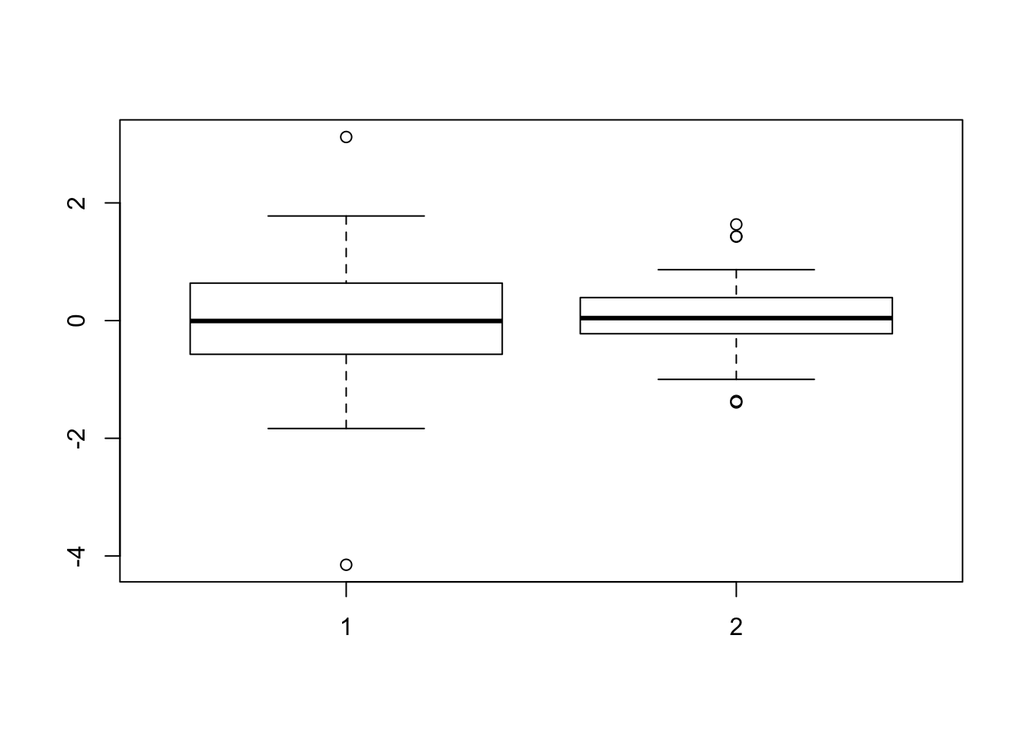

```r
set.seed(1000)
x = rt(n = 20, df = 2.01)
y = rt(n = 20, df = 10)
boxplot(x,y)
```

```r
SiegelTukey(x, y)
```

```
##         Wr   mean(Wr) st.dev(Wr) pval.simul  pval.norm       Nsim
##   3.88e+02   4.10e+02   3.70e+01   2.77e-01   2.80e-01   1.00e+04
```

The $p$-value is .277, so we would fail to reject that the dispersions differ. Siegel-Tukey is well-known to have poor power, unfortunately.